# R Crash course program

Fabio Favoretto

4/15/2019

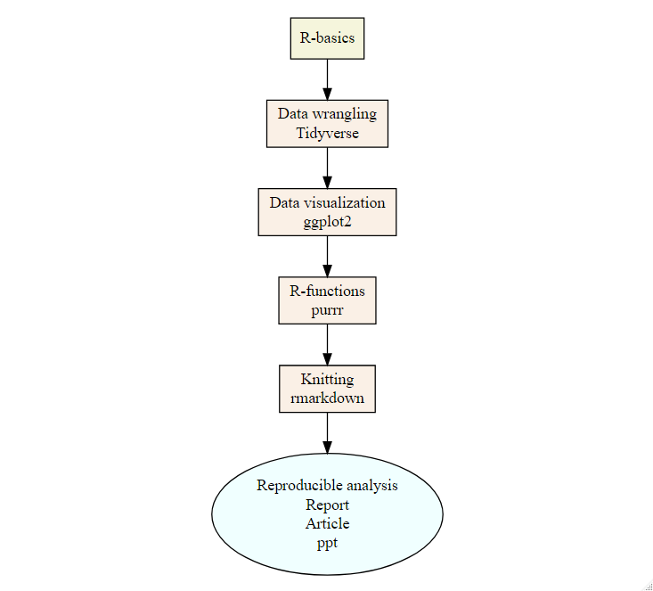

Course scheme

# Day 1

# 1.1. R-basics

- Course presentation;
- How to prepare a working directory (rules of good data science);
- File names and type of data files;
- The R studio IDE;
- Reading and Writing Data;
- Scripting;
- Packages (and GitHub);
- Ask for help;

# 1.2. Workflow basics

- Using the console
- Practice
- Using the scripts
- Practice

# Day 2

# 2. Data wrangling

- Welcome to the `Tidyverse`;
- `filter()` #Pick observations by their values
- `arrange()` #Reorder the rows
- `select()` #Pick variables by their names
- `mutate()` #Create new variables with functions of existing variables
- `summarise()` #Collapse many values down to a single summary
- `group_by()` #which changes the scope of each function from the entire dataset to a group
- saving data

#### 2.1. Fishing effort exercise 1

# 3. Data visualization

- Welcome to ggplot2
- Exploratory data analysis
- Data visualization

#### 3.1. Fishing effort exercise 2

# Day 3

# 4. R-functions and iterations

- R-functions and shortcuts;
- The `purrr` package;

# 5. Knitting

- the `rmarkdown` package;

# Weblinks

## R-programming info

List of R coding resources I have been compiling over the years, feel free to suggest links to be added below in the chat

## Basics

R for data science: https://r4ds.had.co.nz/ Modern R dive: https://moderndive.com/index.html Data wrangling with R: https://cengel.github.io/R-data-wrangling/ The Tidyverse style guide: https://style.tidyverse.org/index.html aRrgh: a newcomer’s (angry) guide to R: http://arrgh.tim-smith.us/ YaRrr! The Pirate’s Guide to R: https://bookdown.org/ndphillips/YaRrr/

## Advanced

Advanced R: https://adv-r.hadley.nz/ Efficient R programming: https://bookdown.org/csgillespie/efficientR/ R programming for Data Science: https://bookdown.org/rdpeng/rprogdatascience/ Hands on programming with R: https://rstudio-education.github.io/hopr/ What They Forgot to Teach You About R: https://rstats.wtf/

## Visualization

Fundamentals of data visualization: https://serialmentor.com/dataviz/ Interactive animations: https://plotly-r.com/ Top 50 visualization with R: http://r-statistics.co/Top50-Ggplot2-Visualizations-MasterList-R-Code.html The R graph gallery: https://www.r-graph-gallery.com/ Graphs cookbook: http://www.cookbook-r.com/Graphs/ Esquisse: https://dreamrs.github.io/esquisse/index.html Diagrams: http://rich-iannone.github.io/DiagrammeR/

## Strings handlings

Text mining with R: https://www.tidytextmining.com/ Handling Strings With R: https://www.gastonsanchez.com/r4strings/intro.html Fulltext: https://docs.ropensci.org/fulltext/articles/fulltext.html

## Documents creation

Rmarkdown definitive guide: https://bookdown.org/yihui/rmarkdown/ Bookdown & blogdown: https://bookdown.org/

## Statistics

ModernDive: https://moderndive.com/ Forecasting: Principles and Practice (2nd ed): https://otexts.com/fpp2/ MANOVA: https://rpubs.com/collnell/manova PCA: https://www.datacamp.com/community/tutorials/pca-analysis-r PCA with factomine: http://www.sthda.com/english/articles/21-courses/65-principal-component-analysis-course-using-factominer/ Multivariate analysis: https://rstudio-pubs-static.s3.amazonaws.com/246172_1930ddfb5f064b2bab54b11016ab407e.html Spatial multiscale analysis: https://cloud.r-project.org/web/packages/adespatial/vignettes/tutorial.html Spatiotemporal statistic with R: https://spacetimewithr.org/Spatio-Temporal%20Statistics%20with%20R.pdf Time Series for Fishery Analysis: https://nwfsc-timeseries.github.io/atsa-labs/ Linear Regression for predictive modelling: https://www.dataquest.io/blog/statistical-learning-for-predictive-modeling-r/ GLM for zero-inflated datta: https://fukamilab.github.io/BIO202/04-C-zero-data.html GLMM FAQ: https://bbolker.github.io/mixedmodels-misc/glmmFAQ.html Hierarchical bayesian models: https://opendatascience.com/hierarchical-bayesian-models-in-r/ Heatwaves: https://robwschlegel.github.io/heatwaveR/ Model testing and performance: https://easystats.github.io/performance/index.html Common statistical tests are linear models (or: how to teach stats): https://lindeloev.github.io/tests-as-linear/ Easystats package: https://github.com/easystats/easystats

## git

gitcheasheet: http://ndpsoftware.com/git-cheatsheet.html#loc=local_repo; happy git: https://happygitwithr.com/

## Miscellaneous tutorials

Getting started with R and R-studio: https://ourcodingclub.github.io/2016/11/13/intro-to-r.html Coding Club Tutorials: https://ourcodingclub.github.io/tutorials/ Cleaning and visualizing genomic data: http://varianceexplained.org/r/tidy-genomics/ R for Reproducible Scientific Analysis: https://swcarpentry.github.io/r-novice-gapminder/ R-Studio Primers: https://rstudio.cloud/learn/primers General statistic and viz. tutorial: http://r-statistics.co/ How to make a reproducible example: https://stackoverflow.com/questions/5963269/how-to-make-a-great-r-reproducible-example Teaching R to new users: https://simplystatistics.org/2018/07/12/use-r-keynote-2018/ rOpenSci: https://ropensci.org/

## R-club blog

https://cbmc-gcmp.github.io/